```python
import pandas as pd
data = pd.read_csv('./Python/data/boss岗位.csv')
data = data.iloc[:,:-1]
data.shape
data.head()
```

|  | 标题 | 地区 | 公司名 | 公司领域 | 薪资 | 经验 | 规模 | 福利 |
| --- | --- | --- | --- | --- | --- | --- | --- | --- |
| 0 | 数据分析师 | 北京·海淀区·公主坟 | 锐捷网络 | 通信/网络设备 | 20-30K·13薪 | 3-5年本科 | 1000-9999人 | 通讯补贴，节日福利，五险一金，定期体检，带薪年假，餐补，包吃，加班补助，员工旅游，零食下午茶... |
| 1 | 数据分析师 | 上海·浦东新区·张江 | 中电金信 | 计算机软件 | 15-25K | 经验不限本科 | 10000人以上 | 定期体检，节日福利，五险一金，补充医疗保险，带薪年假，零食下午茶 |
| 2 | 数据分析师 | 北京·大兴区·亦庄 | 沃东天骏信息技术 | 电子商务 | 30-60K·14薪 | 5-10年本科 | 10000人以上 | 加班补助，免费班车，带薪年假，定期体检，补充医疗保险，全勤奖，餐补，年终奖，股票期权，节日福... |
| 3 | 数据分析师 | 北京·海淀区·马连洼 | 滴滴 | 移动互联网 | 15-30K·15薪 | 3-5年本科 | 1000-9999人 | 定期体检，补充医疗保险，五险一金 |
| 4 | 数据分析师 | 北京·海淀区·清河 | 小米 | 互联网 | 15-30K·14薪 | 3-5年本科 | 10000人以上 | 餐补，补充医疗保险，股票期权，年终奖，五险一金，定期体检，节日福利，12%公积金，带薪年假 |

```python
data1=data.drop_duplicates(keep='first')
data1.shape
```

```
(2595, 8)
```

```python
data1 = data.rename(columns={'标题':'岗位名'},inplace=False)
data1['城市'] = data['地区'].str[:2]
data1.head()
```

|  | 岗位名 | 地区 | 公司名 | 公司领域 | 薪资 | 经验 | 规模 | 福利 | 城市 |
| --- | --- | --- | --- | --- | --- | --- | --- | --- | --- |
| 0 | 数据分析师 | 北京·海淀区·公主坟 | 锐捷网络 | 通信/网络设备 | 20-30K·13薪 | 3-5年本科 | 1000-9999人 | 通讯补贴，节日福利，五险一金，定期体检，带薪年假，餐补，包吃，加班补助，员工旅游，零食下午茶... | 北京 |
| 1 | 数据分析师 | 上海·浦东新区·张江 | 中电金信 | 计算机软件 | 15-25K | 经验不限本科 | 10000人以上 | 定期体检，节日福利，五险一金，补充医疗保险，带薪年假，零食下午茶 | 上海 |
| 2 | 数据分析师 | 北京·大兴区·亦庄 | 沃东天骏信息技术 | 电子商务 | 30-60K·14薪 | 5-10年本科 | 10000人以上 | 加班补助，免费班车，带薪年假，定期体检，补充医疗保险，全勤奖，餐补，年终奖，股票期权，节日福... | 北京 |
| 3 | 数据分析师 | 北京·海淀区·马连洼 | 滴滴 | 移动互联网 | 15-30K·15薪 | 3-5年本科 | 1000-9999人 | 定期体检，补充医疗保险，五险一金 | 北京 |
| 4 | 数据分析师 | 北京·海淀区·清河 | 小米 | 互联网 | 15-30K·14薪 | 3-5年本科 | 10000人以上 | 餐补，补充医疗保险，股票期权，年终奖，五险一金，定期体检，节日福利，12%公积金，带薪年假 | 北京 |

```python
#data2 = data1.copy()
#data2[['地区一','地区二','地区三']] = data2['地区'].str.split('.',expand=True)
# data2.drop(columns='地区',inplace=True)
# data2
```

```python
data1['规模'] = data1['规模'].str.replace('人','').str.replace('以上','').str.replace('少于','').str.replace('-','+')

#data1['公司规模'] = [ if eval(i)==int for i in data1['公司规模']]
# ind1 = ['互联网' in i for i in job['行业']]
data1.head(5)
# a=list(data1['规模'])
# a1=[]
# for i in a:
#     try:
#         if "+" in i:
#             a1.append(int(eval(i)/2))

#         else:
#             a1.append(int(eval(i)))
#     except:
#          a1.append('nan')
# data1['规模'] =a1
# data1.head(15)
```

[output not shown]

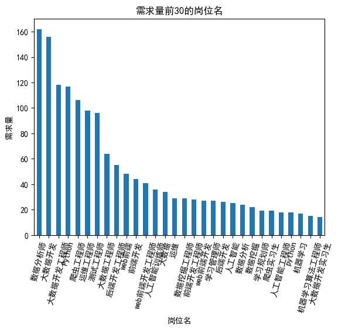

```python
# sort_job = data1[['岗位名']].value_counts()
# sort_job.head(15)
#统计需求量前30的岗位名
import pandas as pd
import matplotlib.pyplot as plt
plt.rcParams["font.sans-serif"]=["SimHei"] ##设置中文显示
plt.rcParams["axes.unicode_minus"]=False ##负的坐标
data1['岗位名'].value_counts().head(30).plot.bar()
# 设置标题和坐标轴标签
plt.title('需求量前30的岗位名')
plt.xlabel('岗位名')
plt.ylabel('需求量')
plt.xticks(rotation=75)
plt.show()
```

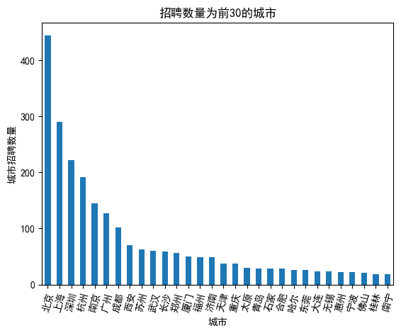

```python
#对地区进行分析
import pandas as pd
import matplotlib.pyplot as plt
plt.rcParams["font.sans-serif"]=["SimHei"] ##设置中文显示
plt.rcParams["axes.unicode_minus"]=False ##负的坐标
data1['城市'].value_counts().head(30).plot.bar()
# 设置标题和坐标轴标签
plt.title('招聘数量为前30的城市')
plt.xlabel('城市')
plt.ylabel('城市招聘数量')
plt.xticks(rotation=75)
plt.show()
```

北京招聘数量明显高于其他城市，位居第一。 上海、深圳、杭州、南京、广州、成都招聘数量依次下降，分为第二级。 苏州到重庆分为第三级。

```python
data1.head(10)
```

|  | 岗位名 | 地区 | 公司名 | 公司领域 | 薪资 | 经验 | 规模 | 福利 | 城市 |
| --- | --- | --- | --- | --- | --- | --- | --- | --- | --- |
| 0 | 数据分析师 | 北京·海淀区·公主坟 | 锐捷网络 | 通信/网络设备 | 20-30K·13薪 | 3-5年本科 | 5499 | 通讯补贴，节日福利，五险一金，定期体检，带薪年假，餐补，包吃，加班补助，员工旅游，零食下午茶... | 北京 |
| 1 | 数据分析师 | 上海·浦东新区·张江 | 中电金信 | 计算机软件 | 15-25K | 经验不限本科 | 10000 | 定期体检，节日福利，五险一金，补充医疗保险，带薪年假，零食下午茶 | 上海 |
| 2 | 数据分析师 | 北京·大兴区·亦庄 | 沃东天骏信息技术 | 电子商务 | 30-60K·14薪 | 5-10年本科 | 10000 | 加班补助，免费班车，带薪年假，定期体检，补充医疗保险，全勤奖，餐补，年终奖，股票期权，节日福... | 北京 |
| 3 | 数据分析师 | 北京·海淀区·马连洼 | 滴滴 | 移动互联网 | 15-30K·15薪 | 3-5年本科 | 5499 | 定期体检，补充医疗保险，五险一金 | 北京 |
| 4 | 数据分析师 | 北京·海淀区·清河 | 小米 | 互联网 | 15-30K·14薪 | 3-5年本科 | 10000 | 餐补，补充医疗保险，股票期权，年终奖，五险一金，定期体检，节日福利，12%公积金，带薪年假 | 北京 |
| 5 | 数据分析师 | 杭州·西湖区·文三路 | 饿了么 | O2O | 25-50K | 5-10年本科 | 10000 | 定期体检，年终奖，股票期权，员工旅游，零食下午茶，包吃，带薪年假，免费班车，交通补助，通讯补... | 杭州 |
| 6 | 数据分析师 | 北京·朝阳区·太阳宫 | BOSS直聘 | 人力资源服务 | 20-30K·16薪 | 1-3年本科 | 5499 | 年终奖，定期体检，带薪年假，交通补助，节日福利，员工旅游，住房补贴，餐补，股票期权，五险一金... | 北京 |
| 7 | 数据分析师 | 佛山·顺德区·北滘 | 美的 | 其他行业 | 18-30K·15薪 | 5-10年本科 | 10000 | 免费班车，通讯补贴，住房补贴，交通补助，游泳池，加班补助，入职补贴2k，员工旅游，餐补，带薪... | 佛山 |
| 8 | 数据分析师 | 深圳·龙岗区·坂田 | 深圳市前海云途物... | 物流/仓储 | 15-22K·13薪 | 3-5年本科 | 5499 | 员工旅游，零食下午茶，节日福利，加班补助，年终奖，五险一金，全勤奖，带薪年假 | 深圳 |
| 9 | 数据分析师 | 北京·朝阳区·望京 | 尔湾科技 | 在线教育 | 15-25K·14薪 | 3-5年本科 | 5499 | 节日福利，定期体检，补充医疗保险，零食下午茶，员工旅游，股票期权，带薪年假，五险一金 | 北京 |

# 公司领域

```python
#公司领域
data1['公司领域1'] = data1['公司领域'].astype(str).str.split('/').str[0]
data1.head(10)
```

|  | 岗位名 | 地区 | 公司名 | 公司领域 | 薪资 | 经验 | 规模 | 福利 | 城市 | 公司领域1 |
| --- | --- | --- | --- | --- | --- | --- | --- | --- | --- | --- |
| 0 | 数据分析师 | 北京·海淀区·公主坟 | 锐捷网络 | 通信/网络设备 | 20-30K·13薪 | 3-5年本科 | 5499 | 通讯补贴，节日福利，五险一金，定期体检，带薪年假，餐补，包吃，加班补助，员工旅游，零食下午茶... | 北京 | 通信 |
| 1 | 数据分析师 | 上海·浦东新区·张江 | 中电金信 | 计算机软件 | 15-25K | 经验不限本科 | 10000 | 定期体检，节日福利，五险一金，补充医疗保险，带薪年假，零食下午茶 | 上海 | 计算机软件 |
| 2 | 数据分析师 | 北京·大兴区·亦庄 | 沃东天骏信息技术 | 电子商务 | 30-60K·14薪 | 5-10年本科 | 10000 | 加班补助，免费班车，带薪年假，定期体检，补充医疗保险，全勤奖，餐补，年终奖，股票期权，节日福... | 北京 | 电子商务 |
| 3 | 数据分析师 | 北京·海淀区·马连洼 | 滴滴 | 移动互联网 | 15-30K·15薪 | 3-5年本科 | 5499 | 定期体检，补充医疗保险，五险一金 | 北京 | 移动互联网 |
| 4 | 数据分析师 | 北京·海淀区·清河 | 小米 | 互联网 | 15-30K·14薪 | 3-5年本科 | 10000 | 餐补，补充医疗保险，股票期权，年终奖，五险一金，定期体检，节日福利，12%公积金，带薪年假 | 北京 | 互联网 |
| 5 | 数据分析师 | 杭州·西湖区·文三路 | 饿了么 | O2O | 25-50K | 5-10年本科 | 10000 | 定期体检，年终奖，股票期权，员工旅游，零食下午茶，包吃，带薪年假，免费班车，交通补助，通讯补... | 杭州 | O2O |
| 6 | 数据分析师 | 北京·朝阳区·太阳宫 | BOSS直聘 | 人力资源服务 | 20-30K·16薪 | 1-3年本科 | 5499 | 年终奖，定期体检，带薪年假，交通补助，节日福利，员工旅游，住房补贴，餐补，股票期权，五险一金... | 北京 | 人力资源服务 |
| 7 | 数据分析师 | 佛山·顺德区·北滘 | 美的 | 其他行业 | 18-30K·15薪 | 5-10年本科 | 10000 | 免费班车，通讯补贴，住房补贴，交通补助，游泳池，加班补助，入职补贴2k，员工旅游，餐补，带薪... | 佛山 | 其他行业 |
| 8 | 数据分析师 | 深圳·龙岗区·坂田 | 深圳市前海云途物... | 物流/仓储 | 15-22K·13薪 | 3-5年本科 | 5499 | 员工旅游，零食下午茶，节日福利，加班补助，年终奖，五险一金，全勤奖，带薪年假 | 深圳 | 物流 |
| 9 | 数据分析师 | 北京·朝阳区·望京 | 尔湾科技 | 在线教育 | 15-25K·14薪 | 3-5年本科 | 5499 | 节日福利，定期体检，补充医疗保险，零食下午茶，员工旅游，股票期权，带薪年假，五险一金 | 北京 | 在线教育 |

```python
y=data1.groupby(by='公司领域1').agg({'公司领域':'count'})
y
y = y.sort_values(by='公司领域',ascending=False)
y.head()
```

| 公司领域1 | 公司领域 |
| --- | --- |
| 计算机软件 | 893 |
| 互联网 | 499 |
| 移动互联网 | 186 |
| 数据服务 | 154 |
| 电子商务 | 120 |

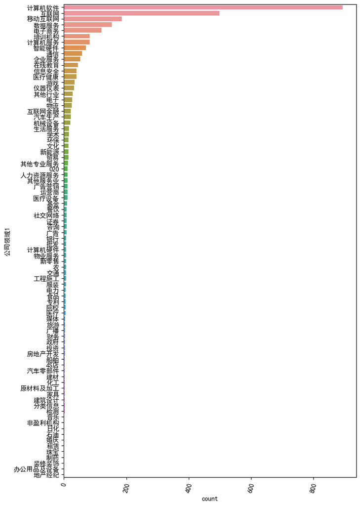

```python
import seaborn as sns
import pandas as pd

plt.figure(figsize=(8,13))
sns.countplot(data=data1, y='公司领域1',orient='v',order=y.index)
plt.xticks(rotation=75)
plt.show()
```

由上图可知，数据分析所涉及的领域非常广泛，其中对数据分析需求量最大的为互联网相关行业； 其次是电商行业、服务行业、教育行业等。

# 公司规模

```python
data1.head()
```

|  | 岗位名 | 地区 | 公司名 | 公司领域 | 薪资 | 经验 | 规模 | 福利 | 城市 | 公司领域1 |
| --- | --- | --- | --- | --- | --- | --- | --- | --- | --- | --- |
| 0 | 数据分析师 | 北京·海淀区·公主坟 | 锐捷网络 | 通信/网络设备 | 20-30K·13薪 | 3-5年本科 | 5499 | 通讯补贴，节日福利，五险一金，定期体检，带薪年假，餐补，包吃，加班补助，员工旅游，零食下午茶... | 北京 | 通信 |
| 1 | 数据分析师 | 上海·浦东新区·张江 | 中电金信 | 计算机软件 | 15-25K | 经验不限本科 | 10000 | 定期体检，节日福利，五险一金，补充医疗保险，带薪年假，零食下午茶 | 上海 | 计算机软件 |
| 2 | 数据分析师 | 北京·大兴区·亦庄 | 沃东天骏信息技术 | 电子商务 | 30-60K·14薪 | 5-10年本科 | 10000 | 加班补助，免费班车，带薪年假，定期体检，补充医疗保险，全勤奖，餐补，年终奖，股票期权，节日福... | 北京 | 电子商务 |
| 3 | 数据分析师 | 北京·海淀区·马连洼 | 滴滴 | 移动互联网 | 15-30K·15薪 | 3-5年本科 | 5499 | 定期体检，补充医疗保险，五险一金 | 北京 | 移动互联网 |
| 4 | 数据分析师 | 北京·海淀区·清河 | 小米 | 互联网 | 15-30K·14薪 | 3-5年本科 | 10000 | 餐补，补充医疗保险，股票期权，年终奖，五险一金，定期体检，节日福利，12%公积金，带薪年假 | 北京 | 互联网 |

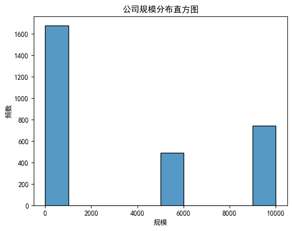

```python
#总体公司规模分布
import seaborn as sns
import matplotlib.pyplot as plt
# 假设公司规模数据存储在名为'scale'的列中
sns.histplot(data=data1, x='规模' ,bins=10)
plt.xlabel('规模')
plt.ylabel('频数')
plt.title('公司规模分布直方图')
plt.show()
```

```python
data1
data_city=data1.groupby(by='城市').agg({'规模':'mean'}).sort_values(by='规模',ascending=False)
data_city.head()
```

| 城市 | 规模 |
| --- | --- |
| 芜湖 | 10000.0 |
| 钦州 | 10000.0 |
| 荆州 | 10000.0 |
| 柳州 | 10000.0 |
| 江门 | 10000.0 |

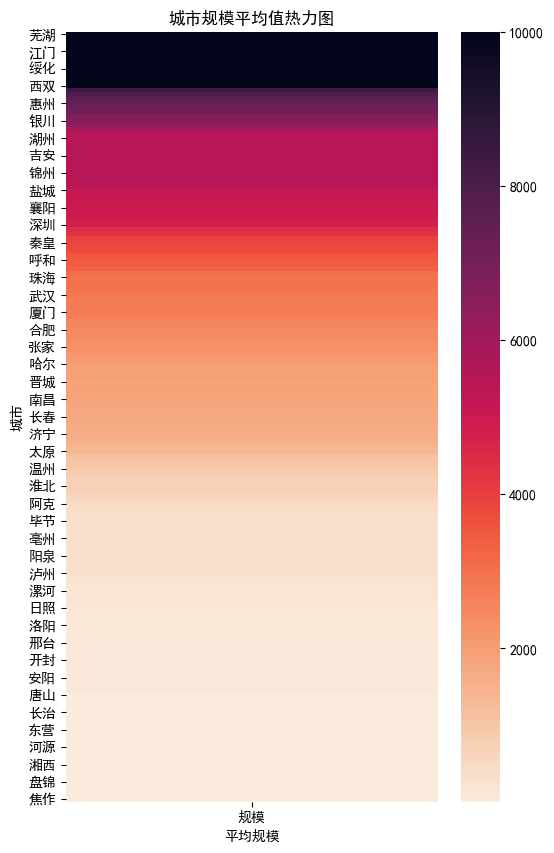

```python
import seaborn as sns
import matplotlib.pyplot as plt
plt.figure(figsize=(6,10))

# 设置颜色映射
cmap = sns.cm.rocket_r

# 绘制热力图
sns.heatmap(data_city, cmap=cmap)

plt.title("城市规模平均值热力图")
plt.xlabel("平均规模")
plt.ylabel("城市")

# 显示图表
plt.show()
```